# Case Study 02

Jeremy Dawkins

11/19/2021

#We will load libraries that we will need in order to use certain functions.

## As part of DDSAnalytics that specializes in talent management solutions we were hired to look at employee data at a firm to determine factors in attrition at the firm. We will examine various aspects of this dataset using explanatory data set to discover what we can find that’s backed up by data.

#We will conduct an analysis on various information and discover which factors into an employee attrition.

```
##   ID Age Attrition    BusinessTravel DailyRate             Department
## 1  1  32        No     Travel_Rarely       117                  Sales
## 2  2  40        No     Travel_Rarely      1308 Research & Development
## 3  3  35        No Travel_Frequently       200 Research & Development
## 4  4  32        No     Travel_Rarely       801                  Sales
## 5  5  24        No Travel_Frequently       567 Research & Development
##   DistanceFromHome Education   EducationField EmployeeCount EmployeeNumber
## 1               13         4    Life Sciences             1            859
## 2               14         3          Medical             1           1128
## 3               18         2    Life Sciences             1           1412
## 4                1         4        Marketing             1           2016
## 5                2         1 Technical Degree             1           1646
##   EnvironmentSatisfaction Gender HourlyRate JobInvolvement JobLevel
## 1                       2   Male         73              3        2
## 2                       3   Male         44              2        5
```

[output cut: 33 more lines]

```
##      ID Age Attrition    BusinessTravel DailyRate             Department
## 866 866  48        No     Travel_Rarely       855 Research & Development
## 867 867  32        No        Non-Travel       976                  Sales
## 868 868  47        No     Travel_Rarely       571                  Sales
## 869 869  45        No     Travel_Rarely      1457 Research & Development
## 870 870  35        No Travel_Frequently       138 Research & Development
##     DistanceFromHome Education EducationField EmployeeCount EmployeeNumber
## 866                4         3  Life Sciences             1           1363
## 867               26         4      Marketing             1            333
## 868               14         3        Medical             1           1503
## 869                7         3        Medical             1           1195
## 870                2         3        Medical             1            269
##     EnvironmentSatisfaction Gender HourlyRate JobInvolvement JobLevel
## 866                       4   Male         54              3        3
## 867                       3   Male        100              3        2
```

[output cut: 33 more lines]

```
## 'data.frame':    870 obs. of  36 variables:
##  $ ID                      : int  1 2 3 4 5 6 7 8 9 10 ...
##  $ Age                     : int  32 40 35 32 24 27 41 37 34 34 ...
##  $ Attrition               : chr  "No" "No" "No" "No" ...
##  $ BusinessTravel          : chr  "Travel_Rarely" "Travel_Rarely" "Travel_Frequently" "Travel_Rarely" ...
##  $ DailyRate               : int  117 1308 200 801 567 294 1283 309 1333 653 ...
##  $ Department              : chr  "Sales" "Research & Development" "Research & Development" "Sales" ...
##  $ DistanceFromHome        : int  13 14 18 1 2 10 5 10 10 10 ...
##  $ Education               : int  4 3 2 4 1 2 5 4 4 4 ...
##  $ EducationField          : chr  "Life Sciences" "Medical" "Life Sciences" "Marketing" ...
##  $ EmployeeCount           : int  1 1 1 1 1 1 1 1 1 1 ...
##  $ EmployeeNumber          : int  859 1128 1412 2016 1646 733 1448 1105 1055 1597 ...
##  $ EnvironmentSatisfaction : int  2 3 3 3 1 4 2 4 3 4 ...
##  $ Gender                  : chr  "Male" "Male" "Male" "Female" ...
##  $ HourlyRate              : int  73 44 60 48 32 32 90 88 87 92 ...
```

[output cut: 22 more lines]

```
##        ID             Age         Attrition         BusinessTravel
##  Min.   :  1.0   Min.   :18.00   Length:870         Length:870
##  1st Qu.:218.2   1st Qu.:30.00   Class :character   Class :character
##  Median :435.5   Median :35.00   Mode  :character   Mode  :character
##  Mean   :435.5   Mean   :36.83
##  3rd Qu.:652.8   3rd Qu.:43.00
##  Max.   :870.0   Max.   :60.00
##    DailyRate       Department        DistanceFromHome   Education
##  Min.   : 103.0   Length:870         Min.   : 1.000   Min.   :1.000
##  1st Qu.: 472.5   Class :character   1st Qu.: 2.000   1st Qu.:2.000
##  Median : 817.5   Mode  :character   Median : 7.000   Median :3.000
##  Mean   : 815.2                      Mean   : 9.339   Mean   :2.901
##  3rd Qu.:1165.8                      3rd Qu.:14.000   3rd Qu.:4.000
##  Max.   :1499.0                      Max.   :29.000   Max.   :5.000
##  EducationField     EmployeeCount EmployeeNumber   EnvironmentSatisfaction
##  Length:870         Min.   :1     Min.   :   1.0   Min.   :1.000
##  Class :character   1st Qu.:1     1st Qu.: 477.2   1st Qu.:2.000
##  Mode  :character   Median :1     Median :1039.0   Median :3.000
##                     Mean   :1     Mean   :1029.8   Mean   :2.701
##                     3rd Qu.:1     3rd Qu.:1561.5   3rd Qu.:4.000
##                     Max.   :1     Max.   :2064.0   Max.   :4.000
##     Gender            HourlyRate     JobInvolvement     JobLevel
##  Length:870         Min.   : 30.00   Min.   :1.000   Min.   :1.000
##  Class :character   1st Qu.: 48.00   1st Qu.:2.000   1st Qu.:1.000
##  Mode  :character   Median : 66.00   Median :3.000   Median :2.000
##                     Mean   : 65.61   Mean   :2.723   Mean   :2.039
##                     3rd Qu.: 83.00   3rd Qu.:3.000   3rd Qu.:3.000
##                     Max.   :100.00   Max.   :4.000   Max.   :5.000
##    JobRole          JobSatisfaction MaritalStatus      MonthlyIncome
##  Length:870         Min.   :1.000   Length:870         Min.   : 1081
##  Class :character   1st Qu.:2.000   Class :character   1st Qu.: 2840
##  Mode  :character   Median :3.000   Mode  :character   Median : 4946
##                     Mean   :2.709                      Mean   : 6390
##                     3rd Qu.:4.000                      3rd Qu.: 8182
##                     Max.   :4.000                      Max.   :19999
##   MonthlyRate    NumCompaniesWorked    Over18            OverTime
##  Min.   : 2094   Min.   :0.000      Length:870         Length:870
##  1st Qu.: 8092   1st Qu.:1.000      Class :character   Class :character
##  Median :14074   Median :2.000      Mode  :character   Mode  :character
##  Mean   :14326   Mean   :2.728
```

[output cut: 15 more lines]

```
##  Max.   :3.0000   Max.   :40.00     Max.   :6.000         Max.   :4.000
##  YearsAtCompany   YearsInCurrentRole YearsSinceLastPromotion
##  Min.   : 0.000   Min.   : 0.000     Min.   : 0.000
##  1st Qu.: 3.000   1st Qu.: 2.000     1st Qu.: 0.000
##  Median : 5.000   Median : 3.000     Median : 1.000
##  Mean   : 6.962   Mean   : 4.205     Mean   : 2.169
##  3rd Qu.:10.000   3rd Qu.: 7.000     3rd Qu.: 3.000
##  Max.   :40.000   Max.   :18.000     Max.   :15.000
##  YearsWithCurrManager
##  Min.   : 0.00
##  1st Qu.: 2.00
##  Median : 3.00
##  Mean   : 4.14
##  3rd Qu.: 7.00
##  Max.   :17.00
```

## As we do our EDA let’s look first look at the departments

#We will look at the summary to look at many people are in each department. #We will go ahead and make factors to use later when trying to graphically represent this data, but also show observations on separate groups.

```
##        Human Resources Research & Development                  Sales
##                     35                    562                    273
```

```
##    Length     Class      Mode
##       870 character character
```

#We will examine the data by Departments to focus on any specific detailed information #We will look at the Sales department specifically here in this section ## We can see here that Attrition did occur in the Sales Department, so we will look at their survey results. #We discover from the Relationship Plot with Attrition; we discover that people with the Manager Job Role on average did not have well relationships with their superiors.

#We also wanted to look at the people who currently still works at the firm and how their surveys looked. #We discover on average their surveys whether it was relationship satisfaction, job involvement, or job satisfaction they had an overall wonderful experience.

#So, we would need to keep in the back of our mind, what would cause these employees to leave when the Sales Department as a group tends to have overall high surveys across all Job Levels and Job Roles they have within the department. #Could this be a money, distance from work, stock options, etc.? We will have to dig further, but for now we will look at this same survey for other departments.

[figure not shown]

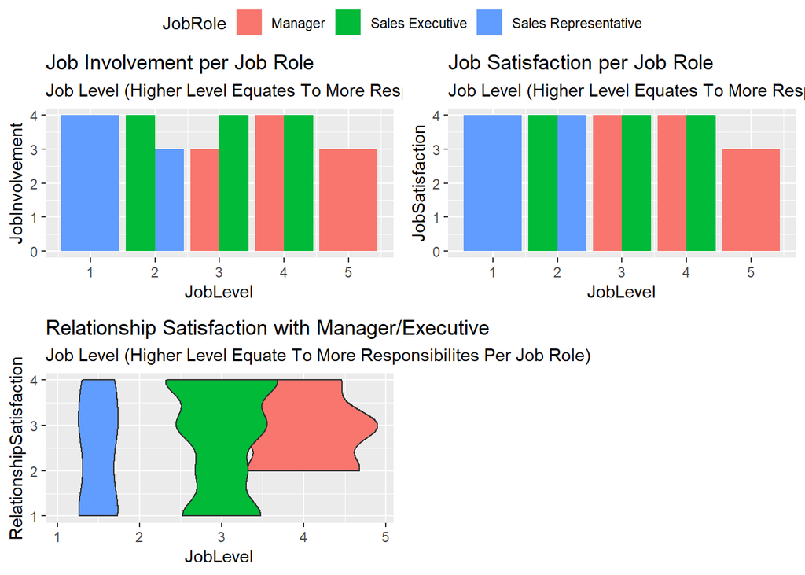

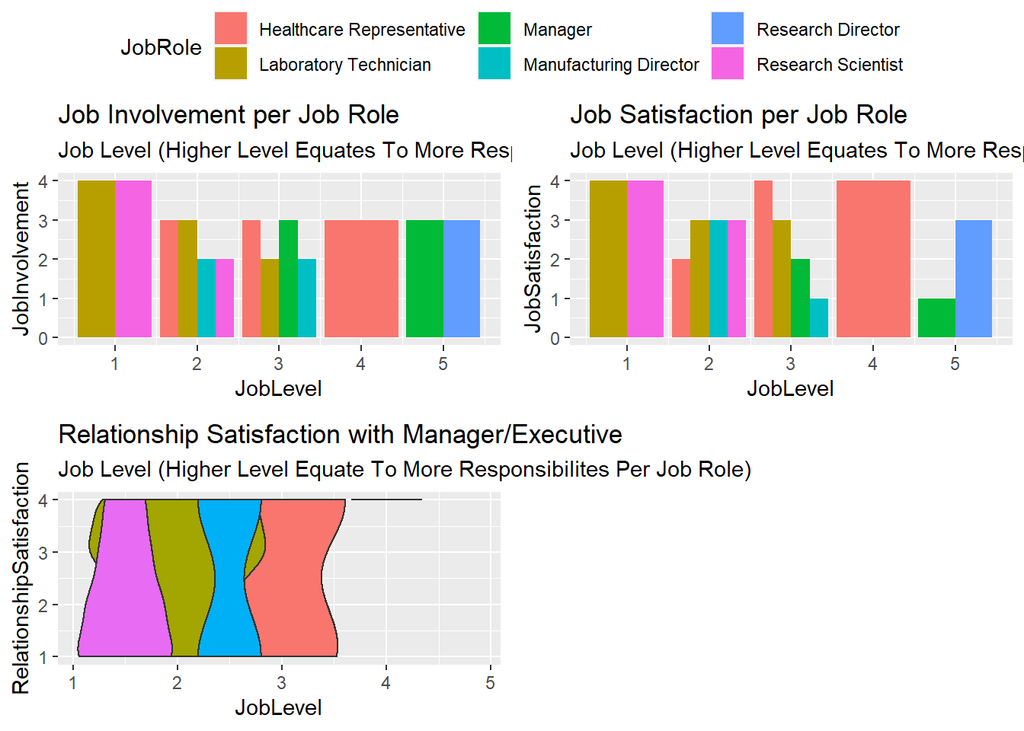

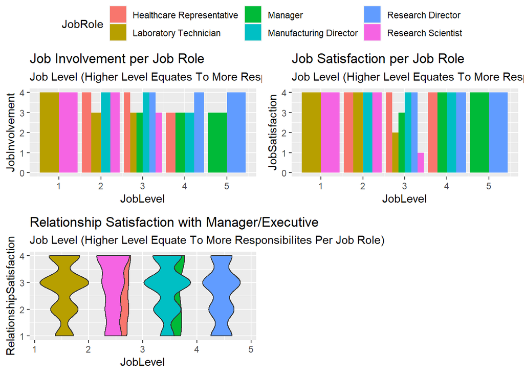

#In this section we will examine the HR Department. We would want to look at similar aspect compared to the other two departments we examined. #In this section we see there are only two job roles in this department, one labeled Human Resources and the other labeled Manager #We also see the people who are now former employees are only Human Resources Job Roles. #Their overall Relationship Satisfaction between employee and managers on average seems to be around the grade 3 (Happy). We will need to examine further what other factors caused these employees to leave.

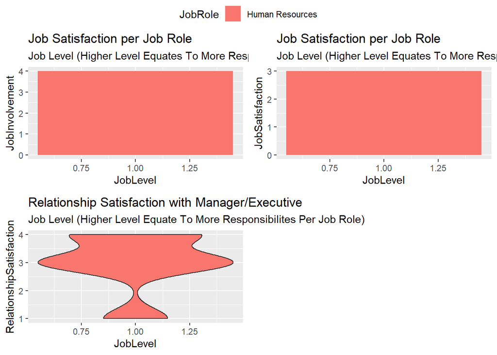

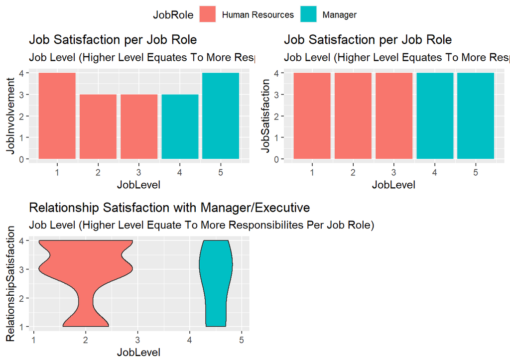

#After discovering interesting facts about variables that could be factors in attrition. Now we will look at majority of the variables here to see which variables are correlated between each other. If these variables are correlated between each other then we would need to take them out and not use them in our potential model. This is since multiple factors trying to explain our model in the next section will not achieve anything and could be overfitting the model. We were able to find a model that best fit and look at the evidence to back up our model. We will also conduct a classification model with Naive Bayes to see sensitivity and specificity.

```
##  [1] "ID"                       "Age"
##  [3] "Attrition"                "BusinessTravel"
##  [5] "DailyRate"                "Department"
##  [7] "DistanceFromHome"         "Education"
##  [9] "EducationField"           "EmployeeCount"
## [11] "EmployeeNumber"           "EnvironmentSatisfaction"
## [13] "Gender"                   "HourlyRate"
## [15] "JobInvolvement"           "JobLevel"
## [17] "JobRole"                  "JobSatisfaction"
## [19] "MaritalStatus"            "MonthlyIncome"
## [21] "MonthlyRate"              "NumCompaniesWorked"
## [23] "Over18"                   "OverTime"
## [25] "PercentSalaryHike"        "PerformanceRating"
## [27] "RelationshipSatisfaction" "StandardHours"
## [29] "StockOptionLevel"         "TotalWorkingYears"
## [31] "TrainingTimesLastYear"    "WorkLifeBalance"
## [33] "YearsAtCompany"           "YearsInCurrentRole"
## [35] "YearsSinceLastPromotion"  "YearsWithCurrManager"
```

```
## 'data.frame':    870 obs. of  29 variables:
##  $ Attrition2              : num  1 1 1 1 1 1 1 1 1 1 ...
##  $ Age                     : int  32 40 35 32 24 27 41 37 34 34 ...
##  $ DailyRate               : int  117 1308 200 801 567 294 1283 309 1333 653 ...
##  $ DistanceFromHome        : int  13 14 18 1 2 10 5 10 10 10 ...
##  $ Education               : int  4 3 2 4 1 2 5 4 4 4 ...
##  $ EnvironmentSatisfaction : int  2 3 3 3 1 4 2 4 3 4 ...
##  $ HourlyRate              : int  73 44 60 48 32 32 90 88 87 92 ...
##  $ JobInvolvement          : int  3 2 3 3 3 3 4 2 3 2 ...
##  $ JobLevel                : int  2 5 3 3 1 3 1 2 1 2 ...
##  $ JobSatisfaction         : int  4 3 4 4 4 1 3 4 3 3 ...
##  $ MonthlyIncome           : int  4403 19626 9362 10422 3760 8793 2127 6694 2220 5063 ...
##  $ MonthlyRate             : int  9250 17544 19944 24032 17218 4809 5561 24223 18410 15332 ...
##  $ PercentSalaryHike       : int  11 14 11 19 13 21 12 14 19 14 ...
##  $ PerformanceRating       : int  3 3 3 3 3 4 3 3 3 3 ...
##  $ RelationshipSatisfaction: int  3 1 3 3 3 3 1 3 4 2 ...
##  $ StockOptionLevel        : int  1 0 0 2 0 2 0 3 1 1 ...
##  $ TotalWorkingYears       : int  8 21 10 14 6 9 7 8 1 8 ...
##  $ TrainingTimesLastYear   : int  3 2 2 3 2 4 5 5 2 3 ...
##  $ WorkLifeBalance         : int  2 4 3 3 3 2 2 3 3 2 ...
##  $ YearsAtCompany          : int  5 20 2 14 6 9 4 1 1 8 ...
##  $ YearsInCurrentRole      : int  2 7 2 10 3 7 2 0 1 2 ...
##  $ YearsSinceLastPromotion : int  0 4 2 5 1 1 0 0 0 7 ...
##  $ YearsWithCurrManager    : int  3 9 2 7 3 7 3 0 0 7 ...
##  $ MaritalStatus2          : num  1 3 3 2 3 1 2 1 2 2 ...
##  $ Gender2                 : num  2 2 2 1 1 2 2 1 1 2 ...
##  $ BusinessTravel2         : num  3 3 2 3 2 2 3 3 3 2 ...
##  $ Department2             : num  3 2 2 3 2 2 2 3 3 2 ...
##  $ OverTIme2               : num  1 1 1 1 2 1 2 2 2 1 ...
##  $ Department              : Factor w/ 3 levels "Human Resources",..: 3 2 2 3 2 2 2 3 3 2 ...
```

```
##    Attrition2         Age          DailyRate      DistanceFromHome
##  Min.   :1.000   Min.   :18.00   Min.   : 103.0   Min.   : 1.000
##  1st Qu.:1.000   1st Qu.:30.00   1st Qu.: 472.5   1st Qu.: 2.000
##  Median :1.000   Median :35.00   Median : 817.5   Median : 7.000
##  Mean   :1.161   Mean   :36.83   Mean   : 815.2   Mean   : 9.339
##  3rd Qu.:1.000   3rd Qu.:43.00   3rd Qu.:1165.8   3rd Qu.:14.000
##  Max.   :2.000   Max.   :60.00   Max.   :1499.0   Max.   :29.000
##    Education     EnvironmentSatisfaction   HourlyRate     JobInvolvement
##  Min.   :1.000   Min.   :1.000           Min.   : 30.00   Min.   :1.000
##  1st Qu.:2.000   1st Qu.:2.000           1st Qu.: 48.00   1st Qu.:2.000
##  Median :3.000   Median :3.000           Median : 66.00   Median :3.000
##  Mean   :2.901   Mean   :2.701           Mean   : 65.61   Mean   :2.723
##  3rd Qu.:4.000   3rd Qu.:4.000           3rd Qu.: 83.00   3rd Qu.:3.000
##  Max.   :5.000   Max.   :4.000           Max.   :100.00   Max.   :4.000
##     JobLevel     JobSatisfaction MonthlyIncome    MonthlyRate
##  Min.   :1.000   Min.   :1.000   Min.   : 1081   Min.   : 2094
##  1st Qu.:1.000   1st Qu.:2.000   1st Qu.: 2840   1st Qu.: 8092
##  Median :2.000   Median :3.000   Median : 4946   Median :14074
##  Mean   :2.039   Mean   :2.709   Mean   : 6390   Mean   :14326
##  3rd Qu.:3.000   3rd Qu.:4.000   3rd Qu.: 8182   3rd Qu.:20456
##  Max.   :5.000   Max.   :4.000   Max.   :19999   Max.   :26997
##  PercentSalaryHike PerformanceRating RelationshipSatisfaction StockOptionLevel
##  Min.   :11.0      Min.   :3.000     Min.   :1.000            Min.   :0.0000
##  1st Qu.:12.0      1st Qu.:3.000     1st Qu.:2.000            1st Qu.:0.0000
##  Median :14.0      Median :3.000     Median :3.000            Median :1.0000
##  Mean   :15.2      Mean   :3.152     Mean   :2.707            Mean   :0.7839
##  3rd Qu.:18.0      3rd Qu.:3.000     3rd Qu.:4.000            3rd Qu.:1.0000
##  Max.   :25.0      Max.   :4.000     Max.   :4.000            Max.   :3.0000
##  TotalWorkingYears TrainingTimesLastYear WorkLifeBalance YearsAtCompany
##  Min.   : 0.00     Min.   :0.000         Min.   :1.000   Min.   : 0.000
##  1st Qu.: 6.00     1st Qu.:2.000         1st Qu.:2.000   1st Qu.: 3.000
##  Median :10.00     Median :3.000         Median :3.000   Median : 5.000
##  Mean   :11.05     Mean   :2.832         Mean   :2.782   Mean   : 6.962
##  3rd Qu.:15.00     3rd Qu.:3.000         3rd Qu.:3.000   3rd Qu.:10.000
##  Max.   :40.00     Max.   :6.000         Max.   :4.000   Max.   :40.000
##  YearsInCurrentRole YearsSinceLastPromotion YearsWithCurrManager MaritalStatus2
##  Min.   : 0.000     Min.   : 0.000          Min.   : 0.00        Min.   :1.00
##  1st Qu.: 2.000     1st Qu.: 0.000          1st Qu.: 2.00        1st Qu.:2.00
##  Median : 3.000     Median : 1.000          Median : 3.00        Median :2.00
##  Mean   : 4.205     Mean   : 2.169          Mean   : 4.14        Mean   :2.09
##  3rd Qu.: 7.000     3rd Qu.: 3.000          3rd Qu.: 7.00        3rd Qu.:3.00
##  Max.   :18.000     Max.   :15.000          Max.   :17.00        Max.   :3.00
##     Gender2      BusinessTravel2  Department2      OverTIme2
##  Min.   :1.000   Min.   :1.000   Min.   :1.000   Min.   :1.00
##  1st Qu.:1.000   1st Qu.:2.000   1st Qu.:2.000   1st Qu.:1.00
##  Median :2.000   Median :3.000   Median :2.000   Median :1.00
##  Mean   :1.593   Mean   :2.602   Mean   :2.274   Mean   :1.29
##  3rd Qu.:2.000   3rd Qu.:3.000   3rd Qu.:3.000   3rd Qu.:2.00
##  Max.   :2.000   Max.   :3.000   Max.   :3.000   Max.   :2.00
##                   Department
##  Human Resources       : 35
##  Research & Development:562
##  Sales                 :273
##
##
##
```

```
##
## Call:
## lm(formula = Attrition2 ~ . - Department, data = Dataset_Y_Select)
##
## Residuals:
##      Min       1Q   Median       3Q      Max
## -0.59108 -0.20377 -0.08369  0.06904  1.09455
##
## Coefficients:
##                            Estimate Std. Error t value Pr(>|t|)
## (Intercept)               1.363e+00  1.874e-01   7.272 8.11e-13 ***
## Age                      -2.853e-03  1.712e-03  -1.667 0.095934 .
## DailyRate                -1.524e-05  2.788e-05  -0.546 0.584876
## DistanceFromHome          3.318e-03  1.384e-03   2.397 0.016760 *
## Education                -4.773e-03  1.119e-02  -0.427 0.669725
## EnvironmentSatisfaction  -2.594e-02  1.020e-02  -2.542 0.011202 *
## HourlyRate                6.490e-04  5.582e-04   1.163 0.245297
## JobInvolvement           -8.590e-02  1.596e-02  -5.382 9.54e-08 ***
## JobLevel                 -5.253e-02  3.544e-02  -1.482 0.138593
## JobSatisfaction          -4.608e-02  1.009e-02  -4.568 5.65e-06 ***
## MonthlyIncome             5.574e-06  8.239e-06   0.677 0.498878
## MonthlyRate              -1.312e-06  1.576e-06  -0.832 0.405482
## PercentSalaryHike        -1.202e-04  4.814e-03  -0.025 0.980082
## PerformanceRating         1.836e-02  4.914e-02   0.374 0.708706
## RelationshipSatisfaction -1.952e-02  1.010e-02  -1.933 0.053585 .
## StockOptionLevel         -9.484e-03  1.712e-02  -0.554 0.579661
## TotalWorkingYears        -1.619e-03  3.181e-03  -0.509 0.610923
## TrainingTimesLastYear    -1.760e-02  8.789e-03  -2.003 0.045493 *
## WorkLifeBalance          -3.633e-02  1.571e-02  -2.312 0.021031 *
## YearsAtCompany            2.055e-03  4.008e-03   0.513 0.608289
## YearsInCurrentRole       -9.778e-03  5.154e-03  -1.897 0.058156 .
## YearsSinceLastPromotion   1.593e-02  4.632e-03   3.439 0.000612 ***
## YearsWithCurrManager     -9.708e-03  5.084e-03  -1.909 0.056559 .
## MaritalStatus2            8.002e-02  2.040e-02   3.922 9.50e-05 ***
## Gender2                   1.879e-02  2.274e-02   0.826 0.408927
## BusinessTravel2          -3.940e-03  1.663e-02  -0.237 0.812816
## Department2               5.396e-02  2.177e-02   2.479 0.013381 *
## OverTIme2                 2.100e-01  2.458e-02   8.544  < 2e-16 ***
## ---
## Signif. codes:  0 '***' 0.001 '**' 0.01 '*' 0.05 '.' 0.1 ' ' 1
##
## Residual standard error: 0.3254 on 842 degrees of freedom
## Multiple R-squared:  0.2412, Adjusted R-squared:  0.2168
## F-statistic: 9.911 on 27 and 842 DF,  p-value: < 2.2e-16
```

```
## Forward Selection Method
## ---------------------------
##
## Candidate Terms:
##
## 1. Age
## 2. DailyRate
## 3. DistanceFromHome
## 4. Education
## 5. EnvironmentSatisfaction
## 6. HourlyRate
## 7. JobInvolvement
## 8. JobLevel
## 9. JobSatisfaction
## 10. MonthlyIncome
## 11. MonthlyRate
## 12. PercentSalaryHike
## 13. PerformanceRating
## 14. RelationshipSatisfaction
## 15. StockOptionLevel
## 16. TotalWorkingYears
## 17. TrainingTimesLastYear
## 18. WorkLifeBalance
## 19. YearsAtCompany
## 20. YearsInCurrentRole
## 21. YearsSinceLastPromotion
## 22. YearsWithCurrManager
## 23. MaritalStatus2
## 24. Gender2
## 25. BusinessTravel2
## 26. Department2
## 27. OverTIme2
##
## We are selecting variables based on p value...
##
##
## Forward Selection: Step 1
##
## - OverTIme2
##
```

[output cut: 479 more lines]

```
##                    model      Beta    Std. Error    Std. Beta      t        Sig      lower     upper
## -----------------------------------------------------------------------------------------------------
##              (Intercept)     1.380         0.094                 14.702    0.000     1.195     1.564
##                OverTIme2     0.213         0.025        0.263     8.662    0.000     0.165     0.261
##           MaritalStatus2     0.092         0.015        0.181     5.958    0.000     0.062     0.123
##           JobInvolvement    -0.087         0.016       -0.167    -5.508    0.000    -0.118    -0.056
##        TotalWorkingYears    -0.008         0.002       -0.160    -4.513    0.000    -0.011    -0.004
##          JobSatisfaction    -0.047         0.010       -0.141    -4.657    0.000    -0.066    -0.027
##  EnvironmentSatisfaction    -0.030         0.010       -0.089    -2.919    0.004    -0.050    -0.010
##          WorkLifeBalance    -0.040         0.016       -0.078    -2.572    0.010    -0.071    -0.010
##  YearsSinceLastPromotion     0.016         0.004        0.141     3.866    0.000     0.008     0.025
##     YearsWithCurrManager    -0.013         0.004       -0.127    -3.455    0.001    -0.021    -0.006
##         DistanceFromHome     0.003         0.001        0.072     2.373    0.018     0.001     0.006
## RelationshipSatisfaction    -0.020         0.010       -0.061    -2.012    0.045    -0.040     0.000
## -----------------------------------------------------------------------------------------------------
```

```
## Backward Elimination Method
## ---------------------------
##
## Candidate Terms:
##
## 1 . Age
## 2 . DailyRate
## 3 . DistanceFromHome
## 4 . Education
## 5 . EnvironmentSatisfaction
## 6 . HourlyRate
## 7 . JobInvolvement
## 8 . JobLevel
## 9 . JobSatisfaction
## 10 . MonthlyIncome
## 11 . MonthlyRate
## 12 . PercentSalaryHike
## 13 . PerformanceRating
## 14 . RelationshipSatisfaction
## 15 . StockOptionLevel
## 16 . TotalWorkingYears
## 17 . TrainingTimesLastYear
## 18 . WorkLifeBalance
## 19 . YearsAtCompany
## 20 . YearsInCurrentRole
## 21 . YearsSinceLastPromotion
## 22 . YearsWithCurrManager
## 23 . MaritalStatus2
## 24 . Gender2
## 25 . BusinessTravel2
## 26 . Department2
## 27 . OverTIme2
##
## We are eliminating variables based on p value...
##
## - PercentSalaryHike
##
## Backward Elimination: Step 1
##
##  Variable PercentSalaryHike Removed
```

[output cut: 808 more lines]

```
##             (Intercept)     1.375         0.116                 11.813    0.000     1.147     1.604
##                     Age    -0.003         0.001       -0.079    -2.281    0.023    -0.006     0.000
##        DistanceFromHome     0.003         0.001        0.071     2.360    0.018     0.001     0.006
## EnvironmentSatisfaction    -0.026         0.010       -0.078    -2.571    0.010    -0.046    -0.006
##          JobInvolvement    -0.086         0.016       -0.165    -5.474    0.000    -0.117    -0.055
##                JobLevel    -0.038         0.012       -0.113    -3.048    0.002    -0.062    -0.014
##         JobSatisfaction    -0.047         0.010       -0.141    -4.690    0.000    -0.066    -0.027
##   TrainingTimesLastYear    -0.018         0.009       -0.062    -2.040    0.042    -0.035    -0.001
##         WorkLifeBalance    -0.037         0.016       -0.071    -2.363    0.018    -0.068    -0.006
##      YearsInCurrentRole    -0.015         0.004       -0.144    -3.825    0.000    -0.022    -0.007
## YearsSinceLastPromotion     0.015         0.004        0.130     3.545    0.000     0.007     0.023
##          MaritalStatus2     0.084         0.015        0.165     5.427    0.000     0.054     0.114
##             Department2     0.052         0.021        0.075     2.474    0.014     0.011     0.094
##               OverTIme2     0.211         0.024        0.260     8.606    0.000     0.163     0.259
## ----------------------------------------------------------------------------------------------------
```

```
## Stepwise Selection Method
## ---------------------------
##
## Candidate Terms:
##
## 1. Age
## 2. DailyRate
## 3. DistanceFromHome
## 4. Education
## 5. EnvironmentSatisfaction
## 6. HourlyRate
## 7. JobInvolvement
## 8. JobLevel
## 9. JobSatisfaction
## 10. MonthlyIncome
## 11. MonthlyRate
## 12. PercentSalaryHike
## 13. PerformanceRating
## 14. RelationshipSatisfaction
## 15. StockOptionLevel
## 16. TotalWorkingYears
## 17. TrainingTimesLastYear
## 18. WorkLifeBalance
## 19. YearsAtCompany
## 20. YearsInCurrentRole
## 21. YearsSinceLastPromotion
## 22. YearsWithCurrManager
## 23. MaritalStatus2
## 24. Gender2
## 25. BusinessTravel2
## 26. Department2
## 27. OverTIme2
##
## We are selecting variables based on p value...
##
##
## Stepwise Selection: Step 1
##
## - OverTIme2 added
##
```

[output cut: 830 more lines]

```
##                    model      Beta    Std. Error    Std. Beta      t        Sig      lower     upper
## -----------------------------------------------------------------------------------------------------
##              (Intercept)     1.380         0.094                 14.702    0.000     1.195     1.564
##                OverTIme2     0.213         0.025        0.263     8.662    0.000     0.165     0.261
##           MaritalStatus2     0.092         0.015        0.181     5.958    0.000     0.062     0.123
##           JobInvolvement    -0.087         0.016       -0.167    -5.508    0.000    -0.118    -0.056
##        TotalWorkingYears    -0.008         0.002       -0.160    -4.513    0.000    -0.011    -0.004
##          JobSatisfaction    -0.047         0.010       -0.141    -4.657    0.000    -0.066    -0.027
##  EnvironmentSatisfaction    -0.030         0.010       -0.089    -2.919    0.004    -0.050    -0.010
##          WorkLifeBalance    -0.040         0.016       -0.078    -2.572    0.010    -0.071    -0.010
##  YearsSinceLastPromotion     0.016         0.004        0.141     3.866    0.000     0.008     0.025
##     YearsWithCurrManager    -0.013         0.004       -0.127    -3.455    0.001    -0.021    -0.006
##         DistanceFromHome     0.003         0.001        0.072     2.373    0.018     0.001     0.006
## RelationshipSatisfaction    -0.020         0.010       -0.061    -2.012    0.045    -0.040     0.000
## -----------------------------------------------------------------------------------------------------
```

```
## [1] 0.2210361
```

```
## [1] 0.230353
```

```
## [1] 0.2210361
```

```
## [1] 597.6251
```

```
## [1] 600.6937
```

```
## [1] 597.6251
```

```
## [1] 0.2110494
```

```
## [1] 0.2186644
```

```
## [1] 0.2110494
```

```
## [1] 0.3265734
```

```
## [1] 0.3249935
```

```
## [1] 0.3265734
```

```
## [1] 535.6347
```

```
## [1] 529.1663
```

```
## [1] 535.6347
```

```
## [1] 18.34366
```

```
## [1] 12.00564
```

```
## [1] 18.34366
```

```
##
## Call:
## lm(formula = Attrition2 ~ DistanceFromHome + EnvironmentSatisfaction +
##     JobInvolvement + JobLevel + JobSatisfaction + TrainingTimesLastYear +
##     WorkLifeBalance + YearsInCurrentRole + YearsSinceLastPromotion +
##     MaritalStatus2 + Department2 + OverTIme2, data = Dataset_Y_Select)
##
## Residuals:
##      Min       1Q   Median       3Q      Max
## -0.53270 -0.20980 -0.08561  0.05782  1.11529
##
## Coefficients:
##                          Estimate Std. Error t value Pr(>|t|)
## (Intercept)              1.263313   0.105818  11.939  < 2e-16 ***
## DistanceFromHome         0.003241   0.001365   2.374 0.017800 *
## EnvironmentSatisfaction -0.025644   0.010142  -2.528 0.011635 *
## JobInvolvement          -0.087118   0.015819  -5.507 4.82e-08 ***
## JobLevel                -0.050367   0.011232  -4.484 8.31e-06 ***
## JobSatisfaction         -0.046789   0.009972  -4.692 3.15e-06 ***
## TrainingTimesLastYear   -0.017387   0.008732  -1.991 0.046774 *
## WorkLifeBalance         -0.035770   0.015640  -2.287 0.022436 *
## YearsInCurrentRole      -0.014410   0.003800  -3.792 0.000160 ***
## YearsSinceLastPromotion  0.014298   0.004221   3.387 0.000738 ***
## MaritalStatus2           0.086435   0.015453   5.593 2.99e-08 ***
## Department2              0.057495   0.021120   2.722 0.006615 **
## OverTIme2                0.209571   0.024532   8.543  < 2e-16 ***
## ---
## Signif. codes:  0 '***' 0.001 '**' 0.01 '*' 0.05 '.' 0.1 ' ' 1
##
## Residual standard error: 0.3258 on 857 degrees of freedom
## Multiple R-squared:  0.2257, Adjusted R-squared:  0.2148
## F-statistic: 20.81 on 12 and 857 DF,  p-value: < 2.2e-16
```

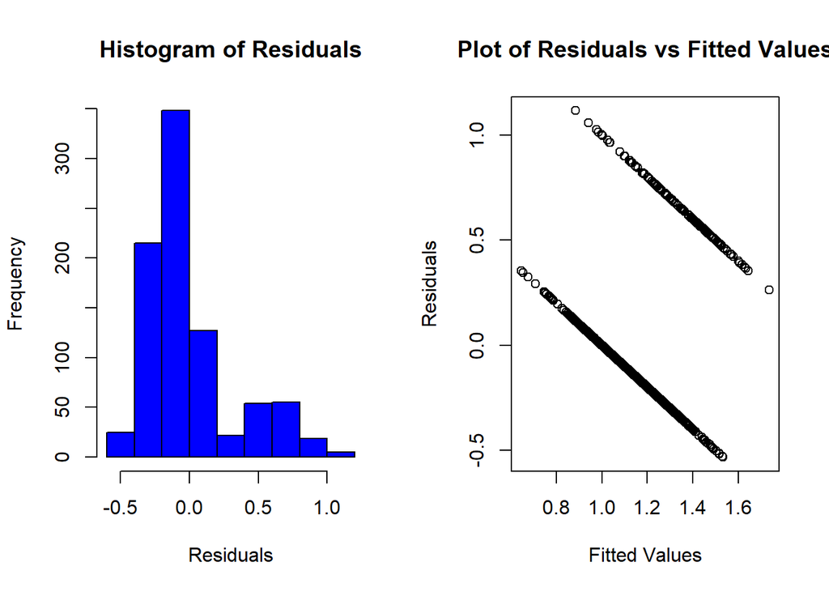

```
##
## Call:
## lm(formula = Attrition2 ~ DistanceFromHome + EnvironmentSatisfaction +
##     JobInvolvement + JobLevel + JobSatisfaction + TrainingTimesLastYear +
##     WorkLifeBalance + YearsInCurrentRole + YearsSinceLastPromotion +
##     MaritalStatus2 + Department2 + OverTIme2, data = Train_Dataset)
##
## Residuals:
##      Min       1Q   Median       3Q      Max
## -0.52932 -0.19979 -0.08276  0.05750  1.13762
##
## Coefficients:
##                          Estimate Std. Error t value Pr(>|t|)
## (Intercept)              1.219620   0.118468  10.295  < 2e-16 ***
## DistanceFromHome         0.003316   0.001567   2.116 0.034695 *
## EnvironmentSatisfaction -0.026979   0.011444  -2.358 0.018698 *
## JobInvolvement          -0.093837   0.018062  -5.195 2.75e-07 ***
## JobLevel                -0.047729   0.012515  -3.814 0.000150 ***
## JobSatisfaction         -0.050318   0.011376  -4.423 1.14e-05 ***
## TrainingTimesLastYear   -0.012326   0.009607  -1.283 0.199942
## WorkLifeBalance         -0.019440   0.017724  -1.097 0.273132
## YearsInCurrentRole      -0.014257   0.004309  -3.309 0.000989 ***
## YearsSinceLastPromotion  0.011351   0.004954   2.291 0.022281 *
## MaritalStatus2           0.082218   0.017399   4.725 2.83e-06 ***
## Department2              0.074880   0.023633   3.168 0.001606 **
## OverTIme2                0.187392   0.027752   6.752 3.27e-11 ***
## ---
## Signif. codes:  0 '***' 0.001 '**' 0.01 '*' 0.05 '.' 0.1 ' ' 1
##
## Residual standard error: 0.3169 on 639 degrees of freedom
## Multiple R-squared:  0.2226, Adjusted R-squared:  0.208
## F-statistic: 15.25 on 12 and 639 DF,  p-value: < 2.2e-16
```

```
##         Rsq      RSME       MAE
## 1 0.2259487 0.3541976 0.2511784
```

```
## [1] 0.2958432
```

```
## Confusion Matrix and Statistics
##
##
##        No Yes
##   No  163  19
##   Yes  16  20
##
##                Accuracy : 0.8394
##                  95% CI : (0.7839, 0.8856)
##     No Information Rate : 0.8211
##     P-Value [Acc > NIR] : 0.2721
##
##                   Kappa : 0.4366
##
##  Mcnemar's Test P-Value : 0.7353
##
##             Sensitivity : 0.9106
##             Specificity : 0.5128
##          Pos Pred Value : 0.8956
##          Neg Pred Value : 0.5556
##              Prevalence : 0.8211
##          Detection Rate : 0.7477
##    Detection Prevalence : 0.8349
##       Balanced Accuracy : 0.7117
##
##        'Positive' Class : No
##
```

```
## [1] 8
```

```
##              (Intercept)                      Age                DailyRate
##                     TRUE                    FALSE                    FALSE
##         DistanceFromHome                Education           EmployeeNumber
##                     TRUE                    FALSE                    FALSE
##  EnvironmentSatisfaction               HourlyRate           JobInvolvement
##                     TRUE                    FALSE                     TRUE
##                 JobLevel          JobSatisfaction              MonthlyRate
##                     TRUE                    FALSE                    FALSE
##       NumCompaniesWorked        PercentSalaryHike        PerformanceRating
##                    FALSE                     TRUE                     TRUE
## RelationshipSatisfaction         StockOptionLevel        TotalWorkingYears
##                    FALSE                    FALSE                     TRUE
##    TrainingTimesLastYear          WorkLifeBalance           YearsAtCompany
##                    FALSE                    FALSE                    FALSE
##       YearsInCurrentRole  YearsSinceLastPromotion     YearsWithCurrManager
##                    FALSE                    FALSE                     TRUE
```

```
##         R2     RMSE      MAE
## 1 0.918827 15720.46 11996.59
```

```
## [1] 0.2044281
```

```
## Linear Regression
##
## 870 samples
##   8 predictor
##
## No pre-processing
## Resampling: Leave-One-Out Cross-Validation
## Summary of sample sizes: 869, 869, 869, 869, 869, 869, ...
## Resampling results:
##
##   RMSE      Rsquared   MAE
##   16527.22  0.9101635  12496.03
##
## Tuning parameter 'intercept' was held constant at a value of TRUE
```

#We will not take the factors that we believe are big impacts to attrition and create different models with them #We will show visuals of the multiple linear regression for Attrition and Salary

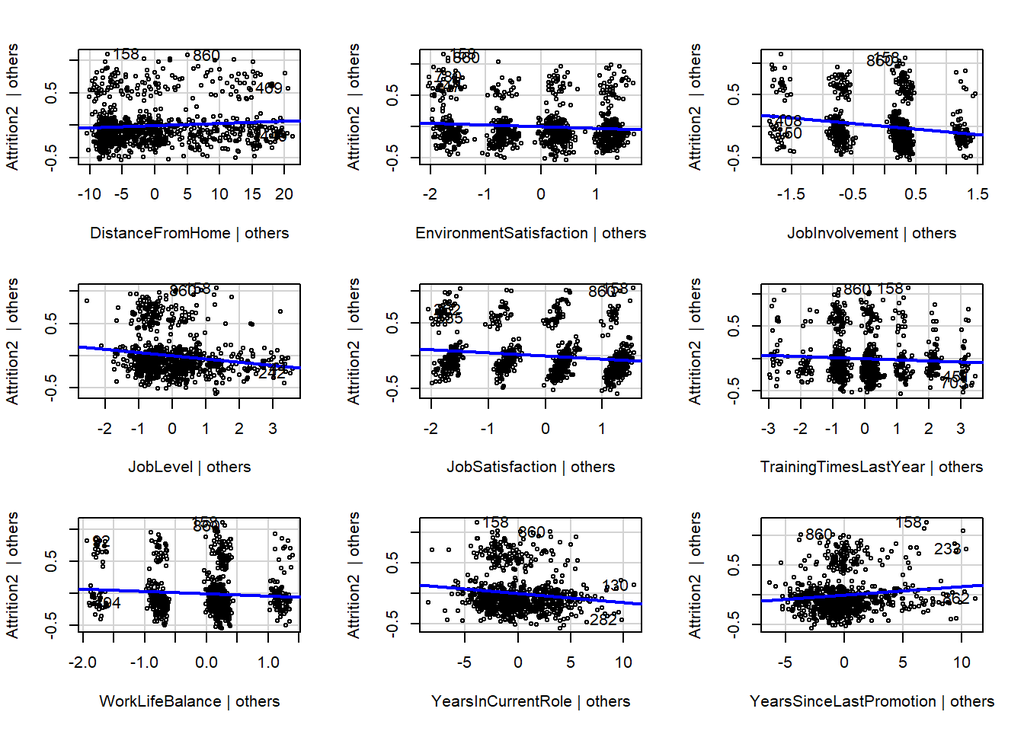

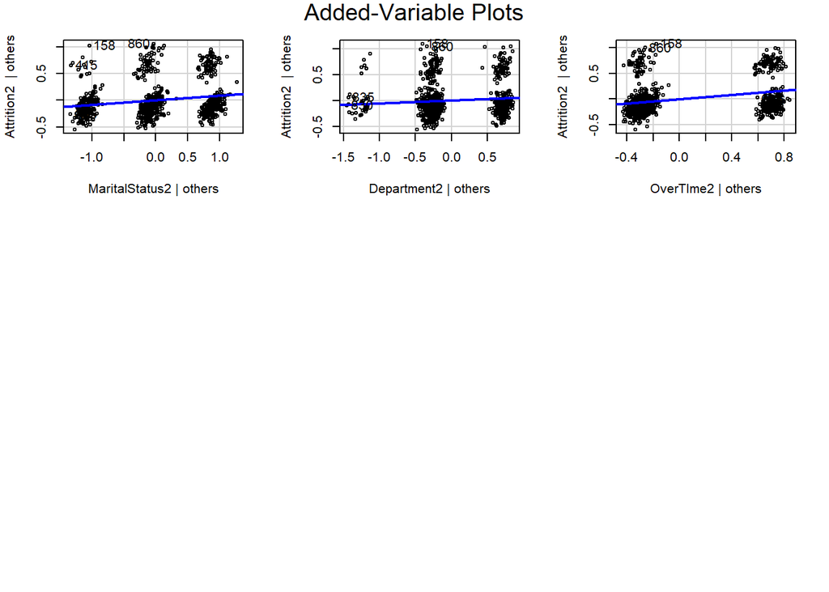

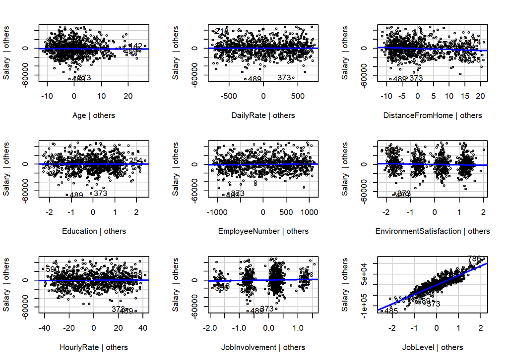

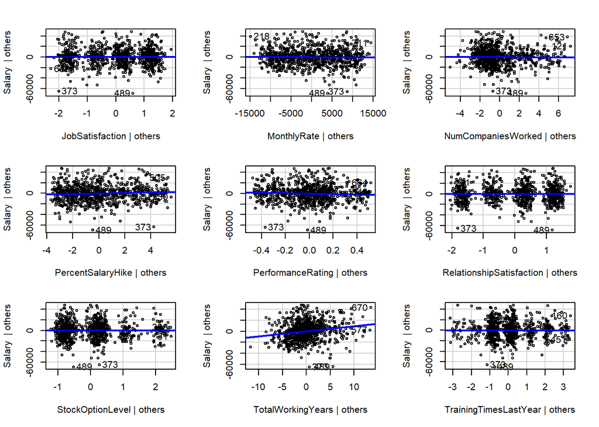

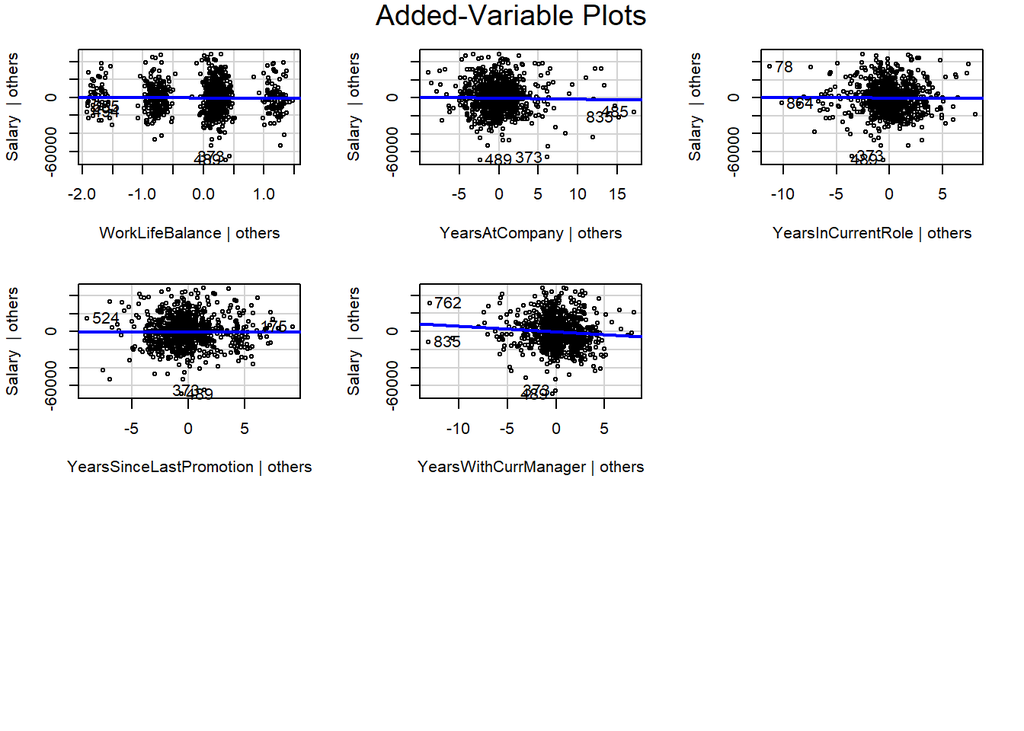

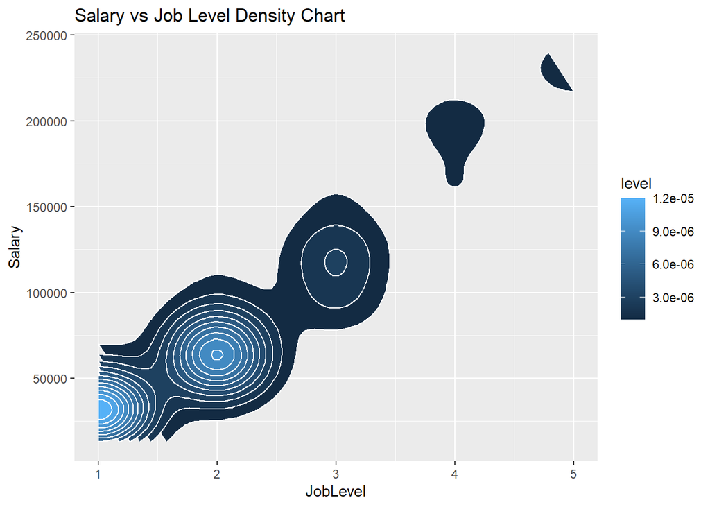

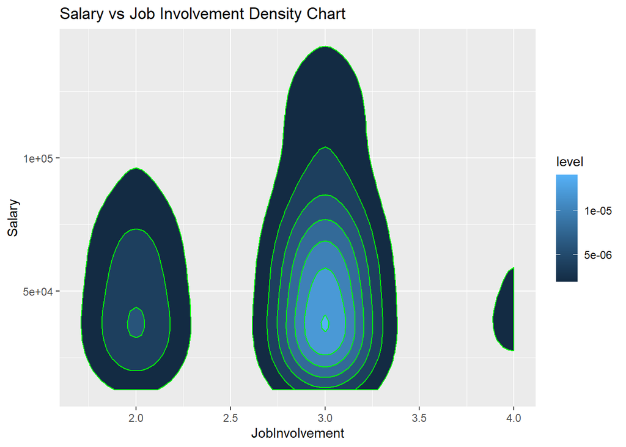

#We will demonstrate some graphs of our models that we created. We display any visuals that the employer can see on what are some low factors they can take into account.

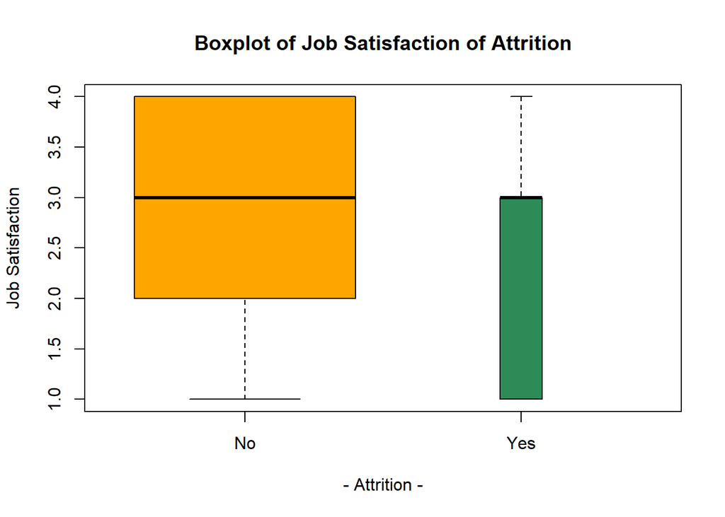

#In conclusion, we discovered that the main factors that leads to attrition are Job Satisfaction, Job Level, Job Involvement, OverTime, Martial Status, and Years in Current Role. These appear to have great significance in whether a employee would stay with the company or leave. Perhaps the company can focus on these areas of weakness and discover what is cause low survey scores that is causing attrition. There could be number of reasons, it will be difficult to narrow it down to only one. The former employees could be poor performers in the workplace which could have an impact on productivity. Any company would not want high attrition rate due to it’s cost like hiring replacements and training them.